# Escalando a través de los datos

Análisis de la base de 8a.nu

Gonzalo Azuaga

**Introducción**

La idea de este Rmarkdown es poder analizar la mayor base de datos de escalada que se encuentra en libre disposición en la actualidad (**The Climbing Log Book Data** creada por David Cohen). La misma puede descargarse del siguiente link: [aqui](https://www.kaggle.com/datasets/dcohen21/8anu-climbing-logbook). Los datos fueron obtenidos a partir de scrappear la página www.8a.nu y corresponden al 13 de septiembre de 2017.

Algunos comentarios a tener en cuenta: Los datos provienen de un sitio web donde los usuarios registran sus escaladas y las personas que se toman la molestia de registrar esta información se toman muy en serio su pasatiempo. Por lo tanto, los datos presentan un fuerte sesgo y tenderán a representar en exceso al escalador serio y fuerte. Esto implica que los grados más bajos no están bien representados en el análisis ya que los principiantes no suelen cargar sus ascensos y los escaladores más avanzados tienden a focalizarse en subir grados más altos.

Por último, los datos reflejan una mayor representación de regiones geográficas donde la plataforma 8a.nu es particularmente popular, principalmente en Europa, lo cual también debe tenerse en cuenta al interpretar los resultados.

El set de datos se puede descargar como una base de datos *sqlite*, pero me resultó más rápido exportar cada de una las 4 tablas que integra la base de datos como archivos .csv individuales (utilizando SQLServer) para luego importarlos a R y analizarlos.

Tablas:

- Ascents: Cuenta con alrededor de 4 millones de escaladas registradas, diferenciando entre la modalidad boulder y escalada deportiva.
- Grade: Una lista de cada uno de los diferentes grados de escalada.
- Usuarios: Aproximadamente 65,000 usuarios.
- Método: Describe el método utilizado para ascender en la escalada.

Estructura de las bases

**EDA**

Data summary

| Name | user |
| --- | --- |
| Number of rows | 62593 |
| Number of columns | 22 |
| _______________________ |  |
| Column type frequency: |  |
| character | 15 |
| numeric | 7 |
| ________________________ |  |
| Group variables | None |

**Variable type: character**

| skim_variable | n_missing | complete_rate | min | max | empty | n_unique | whitespace |
| --- | --- | --- | --- | --- | --- | --- | --- |
| first_name | 0 | 1 | 5 | 5 | 0 | 1 | 0 |
| last_name | 0 | 1 | 4 | 4 | 0 | 1 | 0 |
| city | 0 | 1 | 0 | 30 | 1426 | 16454 | 0 |
| country | 0 | 1 | 0 | 4 | 98 | 215 | 0 |
| competitions | 11 | 1 | 0 | 40 | 57596 | 3356 | 0 |
| occupation | 0 | 1 | 0 | 127 | 50813 | 5339 | 0 |
| sponsor1 | 1 | 1 | 0 | 129 | 57230 | 3846 | 0 |
| sponsor2 | 1 | 1 | 0 | 80 | 59929 | 1884 | 0 |
| sponsor3 | 1 | 1 | 0 | 249 | 61088 | 1129 | 0 |
| best_area | 1 | 1 | 0 | 231 | 47172 | 8912 | 0 |
| worst_area | 0 | 1 | 0 | 59 | 62372 | 213 | 0 |
| guide_area | 6 | 1 | 0 | 224 | 54787 | 6016 | 0 |
| interests | 0 | 1 | 0 | 250 | 54014 | 7374 | 0 |
| birth | 0 | 1 | 0 | 10 | 34737 | 10704 | 0 |
| presentation | 0 | 1 | 0 | 6207 | 56478 | 5951 | 4 |

**Variable type: numeric**

| skim_variable | n_missing | complete_rate | mean | sd | p0 | p25 | p50 | p75 | p100 | hist |
| --- | --- | --- | --- | --- | --- | --- | --- | --- | --- | --- |
| id | 0 | 1 | 33106.41 | 19373.41 | 1 | 16325 | 32721 | 49980 | 67025 | ▇▇▇▇▇ |
| sex | 0 | 1 | 0.16 | 2.07 | 0 | 0 | 0 | 0 | 255 | ▇▁▁▁▁ |
| height | 0 | 1 | 83.88 | 88.16 | 0 | 0 | 0 | 176 | 255 | ▇▁▁▇▁ |
| weight | 0 | 1 | 33.12 | 35.08 | 0 | 0 | 0 | 68 | 100 | ▇▁▂▅▁ |
| started | 0 | 1 | 1071.69 | 999.57 | 0 | 0 | 1992 | 2006 | 2090 | ▇▁▁▁▇ |
| deactivated | 0 | 1 | 0.04 | 0.20 | 0 | 0 | 0 | 0 | 1 | ▇▁▁▁▁ |
| anonymous | 0 | 1 | 0.00 | 0.00 | 0 | 0 | 0 | 0 | 0 | ▁▁▇▁▁ |

Como primera aproximación a los datos se busca saber cuál es el máximo grado de escalada deportiva y de boulder alcanzado por los usuarios. Para ello, se debe estimar la edad, experiencia, y máximo grado escalado por usuario y modalidad (redpoint, onsight/flash).

**Análisis gráfico de variables cuantitativas de interés del dataframe**

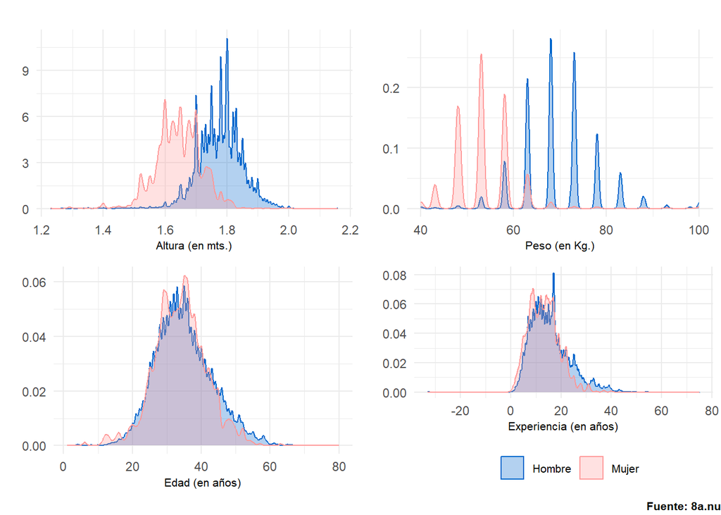

**Estimación del grado máximo escalado por usuario**

Para cada usuario se identificó el máximo grado alcanzado en modalidad redpoint y onsight/flash, tanto en escalada deportiva como en boulder. Junto con el grado, se extrajo el año en que fue registrado ese ascenso como representación del momento de mayor rendimiento declarado.

A partir de esa información, se estimó el tiempo requerido para alcanzar dicho grado calculando la diferencia entre:

- El año del ascenso al máximo grado, y
- El año en que la persona declaró haber comenzado a escalar.

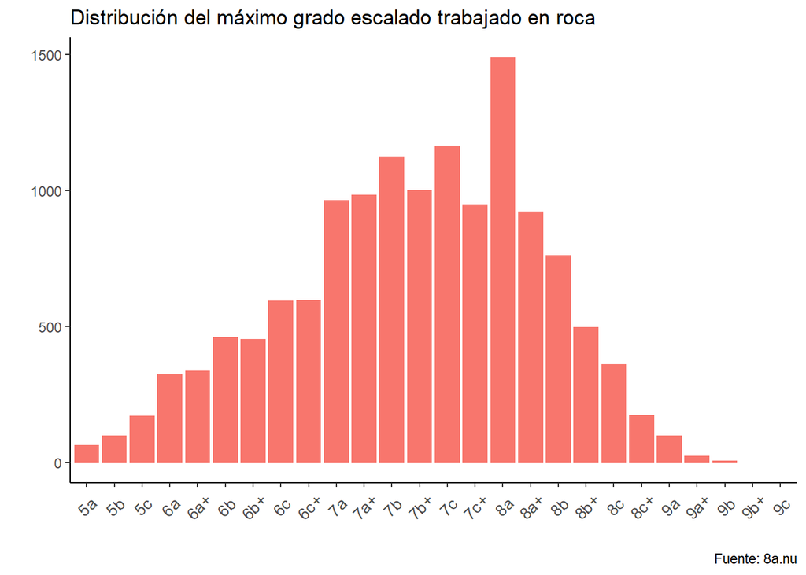

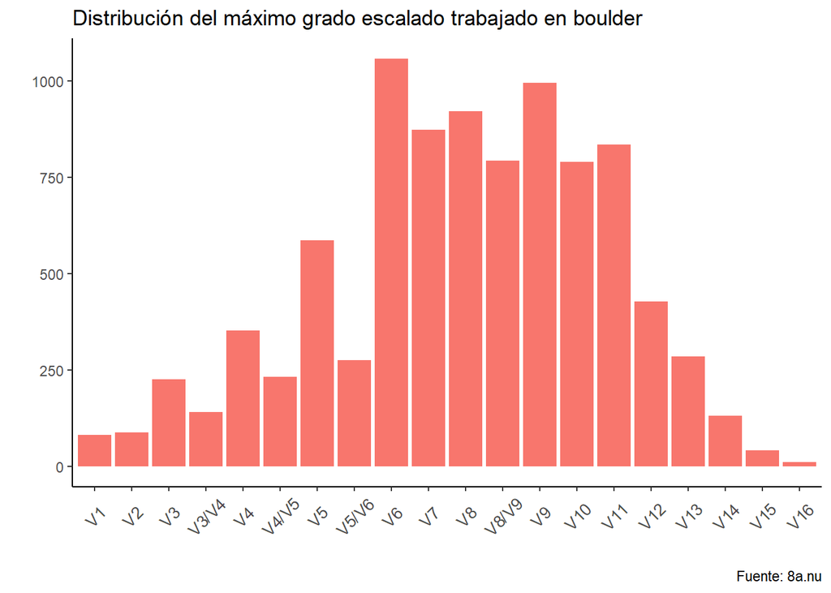

A partir de ambos gráficos se observa que la gran mayoría de las personas reportaron como su máximo grado de escalada en roca el 8a, mientras que en boulder V6.

**Análisis de Escalada en roca**

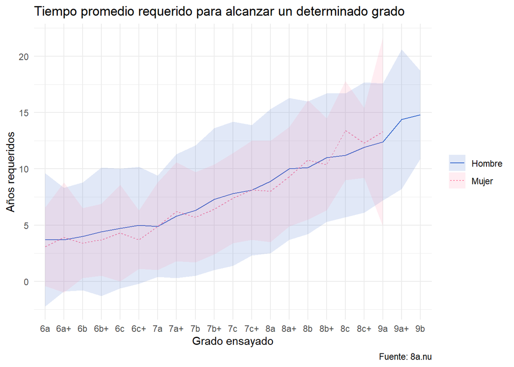

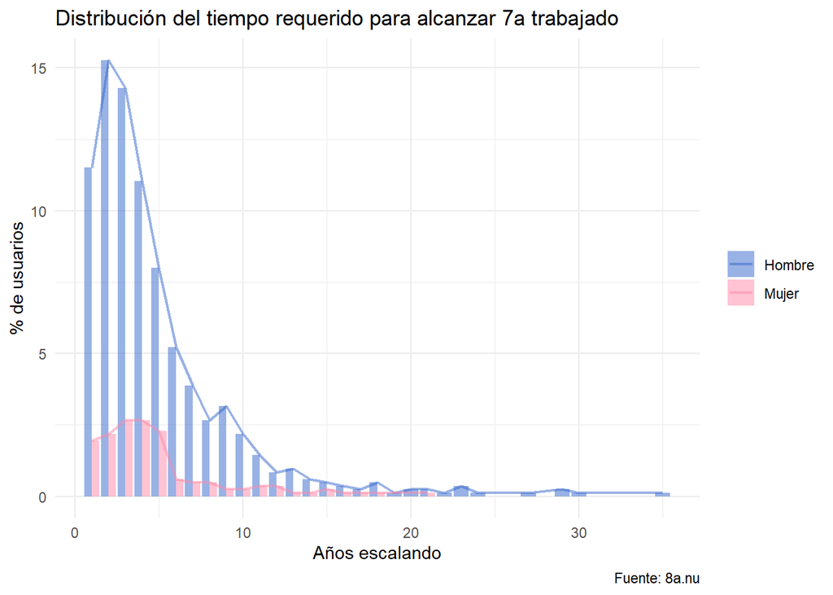

Al profundizar en el tiempo que han necesitado los escaladores para alcanzar un grado concreto (como el 7a), se observa que la gran mayoría lo ha alcanzado entre los 2 y 3 años, mientras que el promedio indica unos 5. Esto se debe a la gran variabilidad que existe en los datos relevados.

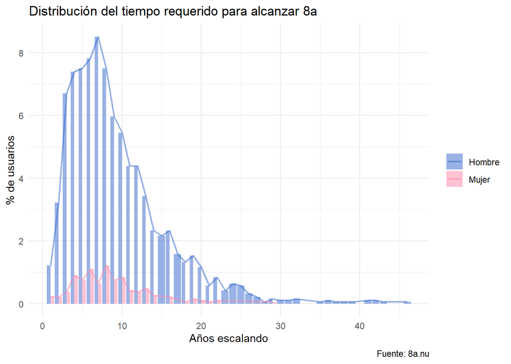

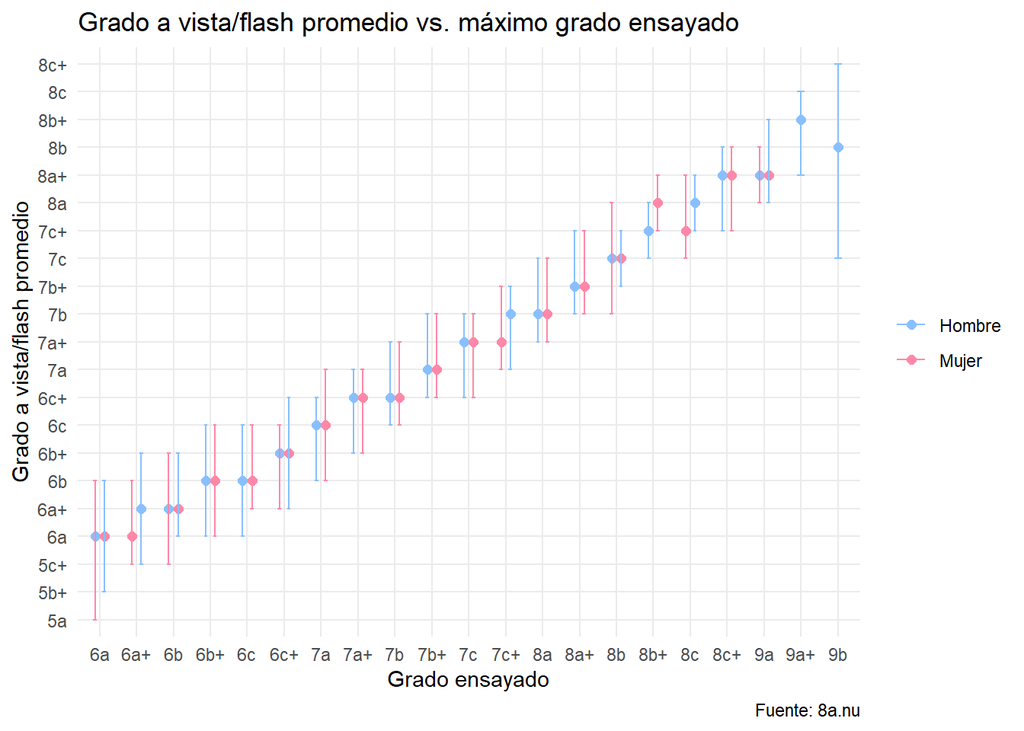

Este gráfico muestra la relación entre el grado máximo alcanzado en modalidad redpoint (ensayado) y el grado máximo en modalidad onsight/flash. La concentración de puntos a lo largo de la diagonal es esperable: quienes alcanzan un alto grado ensayado tienden a mostrar también un alto rendimiento a vista/flash.

Sin embargo, también se observa una notable dispersión alrededor de esa diagonal. Esta variabilidad indica que, para un mismo grado redpoint, existen diferencias marcadas en el grado alcanzado a vista, y viceversa. Los límites superior e inferior representan los valores máximos y mínimos observados para cada nivel redpoint, no un desvío estadístico.

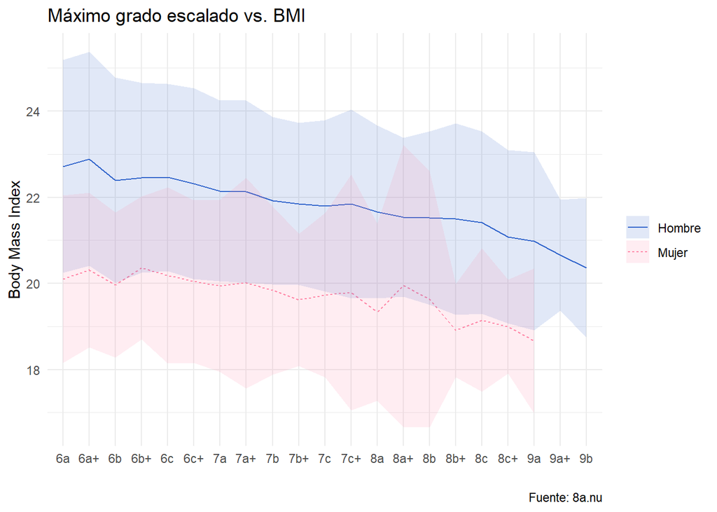

A partir del gráfico anterior se observa que, a medida que aumenta el máximo grado de escalada alcanzado el BMI medio tiende a reducirse como también su variabilidad, aunque de forma leve. Esto se observa en las bandas sombreadas que reflejan el rango de ±1 desvío estándar, proporcionando una medida de dispersión. Cabe resaltar que, para los grados más elevados existen pocos registros, por tal las estimaciones están muy influenciadas por la fisiología de esas personas.

Las tendencias mencionadas pareciesen tener más efecto en el caso de los hombres que de las mujeres. Particularmente, llama la atención el pico que se observa en el grado de 8a+ reportado por las mujeres, podría tratarse de un posible outlier que esté afectando la media como los desvíos standards estimados.

```
## # A tibble: 15 × 5
## # Groups:   fra_routes, sex [1]
##    sex   fra_routes height weight   bmi
##    <chr> <chr>       <dbl>  <int> <dbl>
##  1 Mujer 8a+          1.5      88  39.1
##  2 Mujer 8a+          1.74    100  33.0
##  3 Mujer 8a+          1.6      63  24.6
##  4 Mujer 8a+          1.6      58  22.7
##  5 Mujer 8a+          1.67     63  22.6
##  6 Mujer 8a+          1.62     58  22.1
##  7 Mujer 8a+          1.55     53  22.1
##  8 Mujer 8a+          1.55     53  22.1
##  9 Mujer 8a+          1.57     53  21.5
## 10 Mujer 8a+          1.65     58  21.3
## 11 Mujer 8a+          1.65     58  21.3
## 12 Mujer 8a+          1.66     58  21.0
## 13 Mujer 8a+          1.66     58  21.0
## 14 Mujer 8a+          1.59     53  21.0
## 15 Mujer 8a+          1.52     48  20.8
```

Se observa que dos personas reportaron haber escalado 8a+ como máximo grado y tienen un peso de 88 kg y 100 kg, midiendo 1,50 mts y 1,74 mts respectivamente, lo que genera valores bastante elevados de BMI comparados con el resto de las mujeres que escalaron dicho grado.

*Máximo grado vs. altura*

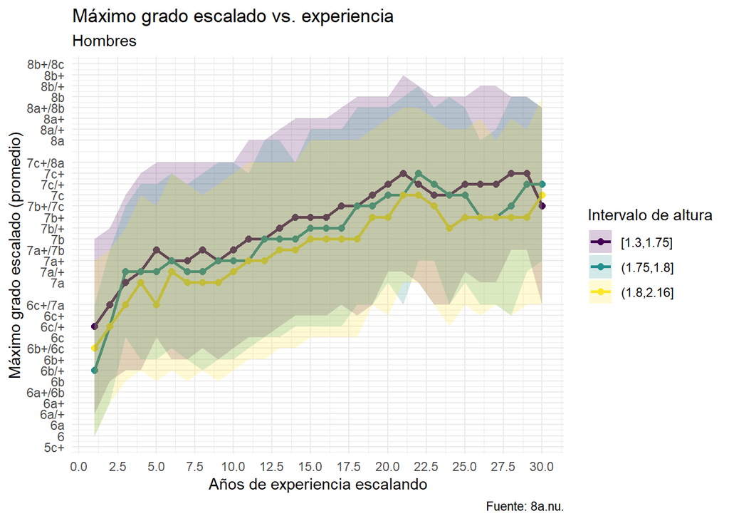

En el caso de los hombres, se observa que aquellos con menor estatura (aproximadamente entre 1,30 m y 1,75 m) tienden a mostrar una progresión más acelerada durante los primeros años de experiencia en la escalada. No obstante, estas tendencias deben interpretarse con cautela, debido al elevado nivel de variabilidad en los datos y a la posible presencia de sesgos muestrales.

En el caso de las mujeres, se optó por no presentar este análisis debido al menor volumen de registros disponibles y al alto grado de ruido observado en los datos, lo que impide extraer conclusiones sólidas o generalizables.

**Altura vs. máximo grado**

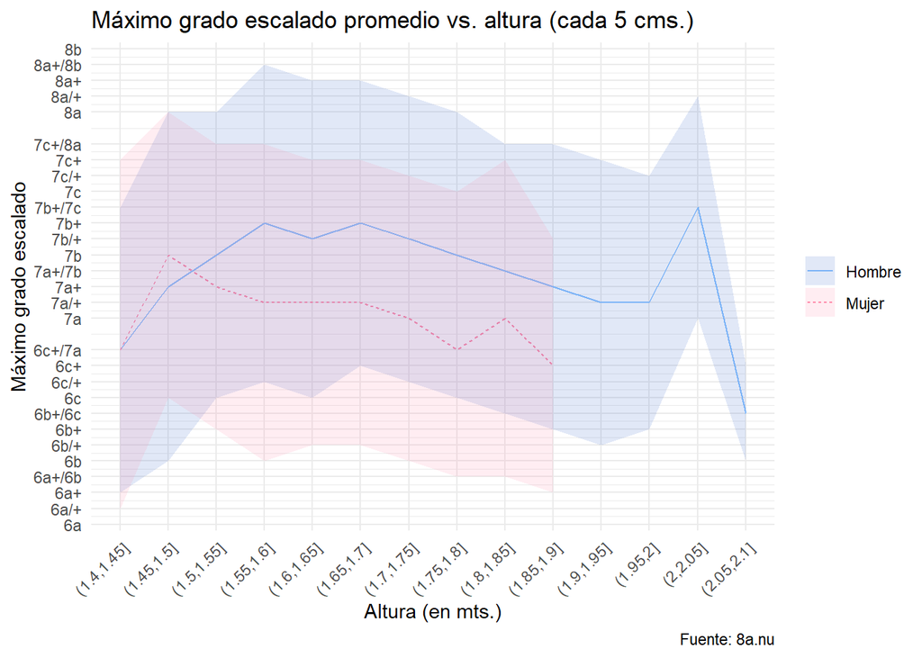

El gráfico revela una tendencia ligeramente negativa entre la altura y el grado máximo de escalada alcanzado tanto en hombres como en mujeres: a medida que aumenta la estatura, el rendimiento promedio tiende a disminuir.

Si bien las diferencias no son extremas, se observa que los escaladores y escaladoras de menor estatura presentan, en promedio, mejores desempeños máximos en relación con sus contrapartes más altas. Esta relación podría explicarse parcialmente por ventajas biomecánicas como una menor masa corporal relativa.

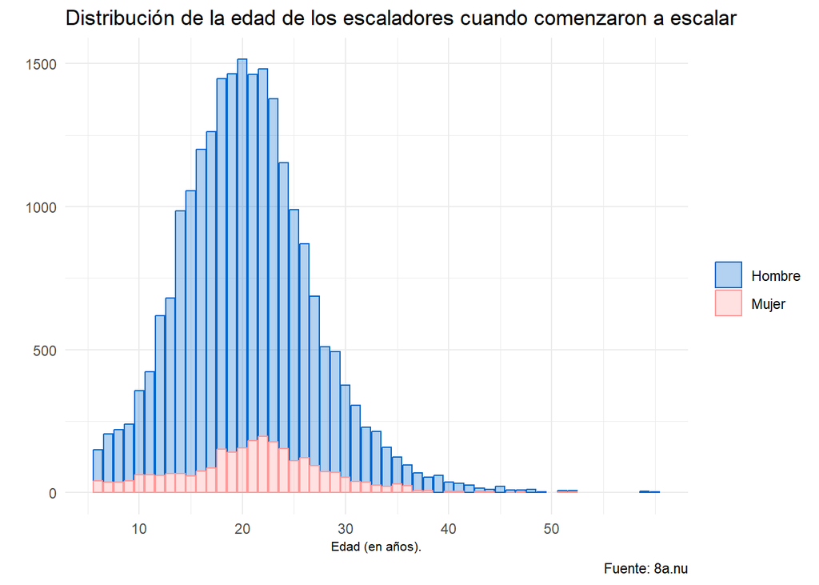

Se observa que la gran mayoría de los escaladores comenzaron a escalar entre los 18 y 22 años aproximadamente, habiendo los hombres, en promedio, comenzado relativamente antes que las mujeres.

Dado que la progresión en el grado máximo alcanzado parece estar influida por múltiples factores, se procedió a ajustar modelos de regresión múltiple para estimar su impacto específico. En particular, se analizaron variables como la edad, la experiencia, la altura y el índice de masa corporal, tanto para hombres como para mujeres.

**Modelización. Regresión múltiple**

*Escalada deportiva (Hombres)*

```
##
## Call:
## lm(formula = grade_id ~ bmi + height + experience + age, data = base_regre_h)
##
## Residuals:
##     Min      1Q  Median      3Q     Max
## -31.883  -5.323   0.963   6.238  23.085
##
## Coefficients:
##              Estimate Std. Error t value            Pr(>|t|)
## (Intercept)  95.25597    2.20520   43.20 <0.0000000000000002 ***
## bmi          -0.65539    0.04036  -16.24 <0.0000000000000002 ***
## height      -11.68540    1.13367  -10.31 <0.0000000000000002 ***
## experience    0.65625    0.01521   43.15 <0.0000000000000002 ***
## age          -0.40107    0.01401  -28.64 <0.0000000000000002 ***
## ---
## Signif. codes:  0 '***' 0.001 '**' 0.01 '*' 0.05 '.' 0.1 ' ' 1
##
## Residual standard error: 8.412 on 10344 degrees of freedom
## Multiple R-squared:  0.1956, Adjusted R-squared:  0.1953
## F-statistic: 628.9 on 4 and 10344 DF,  p-value: < 0.00000000000000022
```

A partir de los resultados obtenidos, es posible sostener que a mayor bmi y altura, en promedio, se obtiene un menor grado escalado. Para poder conocer que variable afecta más sobre el máximo grado escalado, debemos estandarizar las variables predictoras para llevarlas a una misma unidad de medida.

```
##
## Call:
## lm(formula = .outcome ~ ., data = dat)
##
## Residuals:
##     Min      1Q  Median      3Q     Max
## -31.883  -5.323   0.963   6.238  23.085
##
## Coefficients:
##             Estimate Std. Error t value            Pr(>|t|)
## (Intercept) 55.46169    0.08269  670.72 <0.0000000000000002 ***
## bmi         -1.39983    0.08620  -16.24 <0.0000000000000002 ***
## height      -0.85818    0.08326  -10.31 <0.0000000000000002 ***
## experience   4.78088    0.11081   43.15 <0.0000000000000002 ***
## age         -3.28229    0.11463  -28.64 <0.0000000000000002 ***
## ---
## Signif. codes:  0 '***' 0.001 '**' 0.01 '*' 0.05 '.' 0.1 ' ' 1
##
## Residual standard error: 8.412 on 10344 degrees of freedom
## Multiple R-squared:  0.1956, Adjusted R-squared:  0.1953
## F-statistic: 628.9 on 4 and 10344 DF,  p-value: < 0.00000000000000022
```

No obstante, este porcentaje relativamente bajo sugiere que existen otros factores determinantes del rendimiento que no han sido capturados en el modelo. Entre ellos, se destacan variables psicológicas (como la tolerancia al miedo, la motivación y la gestión del estrés), así como capacidades físicas específicas de la escalada (como la fuerza máxima de dedos, la resistencia muscular local, la movilidad y la técnica gestual). Incorporar estas dimensiones en futuros modelos podría mejorar sustancialmente la capacidad explicativa y la comprensión integral del rendimiento en escalada deportiva.

**Supuestos**

*Normalidad*

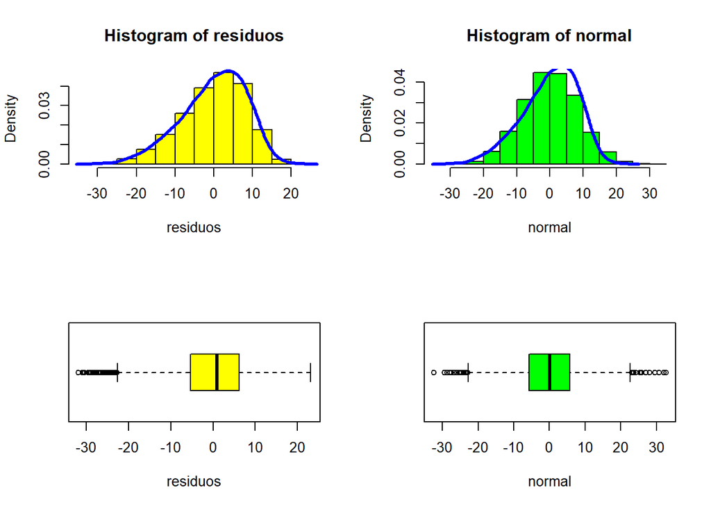

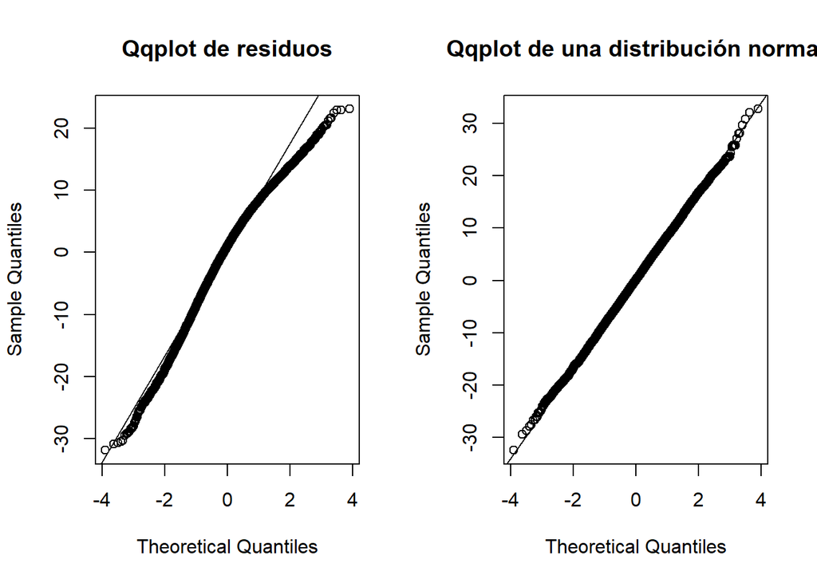

```
##
##  Lilliefors (Kolmogorov-Smirnov) normality test
##
## data:  residuos
## D = 0.047281, p-value < 0.00000000000000022
```

*Homocedasticidad e independencia*

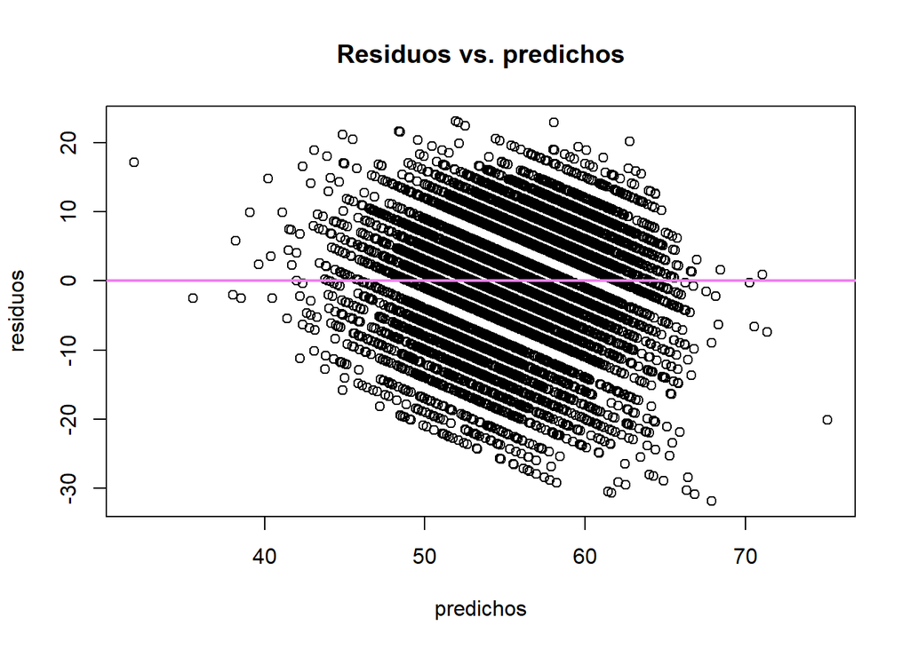

*Sesgo*

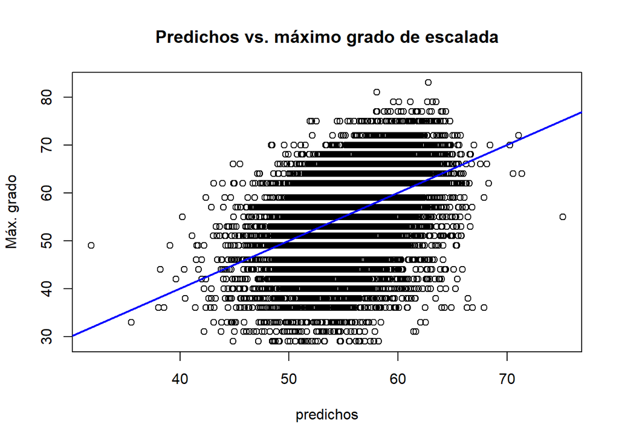

*Multicolinealidad*

*Inflación de la varianza*

```
##        bmi     height experience        age
##   1.086710   1.013675   1.795512   1.921378
```

**Mujeres**

```
##
## Call:
## lm(formula = .outcome ~ ., data = dat)
##
## Residuals:
##      Min       1Q   Median       3Q      Max
## -25.1860  -5.4033   0.8656   6.3026  22.1347
##
## Coefficients:
##             Estimate Std. Error t value             Pr(>|t|)
## (Intercept)  52.0971     0.2378 219.094 < 0.0000000000000002 ***
## bmi          -1.0666     0.2416  -4.414             0.000011 ***
## height       -0.5875     0.2427  -2.421               0.0156 *
## experience    4.4847     0.2768  16.202 < 0.0000000000000002 ***
## age          -2.6482     0.2799  -9.460 < 0.0000000000000002 ***
## ---
## Signif. codes:  0 '***' 0.001 '**' 0.01 '*' 0.05 '.' 0.1 ' ' 1
##
## Residual standard error: 8.633 on 1313 degrees of freedom
## Multiple R-squared:  0.1836, Adjusted R-squared:  0.1811
## F-statistic: 73.82 on 4 and 1313 DF,  p-value: < 0.00000000000000022
```

Estos hallazgos respaldan la importancia de considerar diferencias sexuales en el análisis del rendimiento en escalada, especialmente en cómo factores fisiológicos pueden tener impactos diferenciados. Asimismo, sugieren que modelos separados para cada sexo son apropiados para capturar estas particularidades y mejorar la precisión interpretativa. Cabe destacar que otros factores no incluidos en el modelo —como fuerza específica, técnica y aspectos psicológicos— probablemente contribuyen también de forma importante al rendimiento y deberían considerarse en análisis futuros para mejorar el ajuste del modelo.

**Supuestos**

*Normalidad*

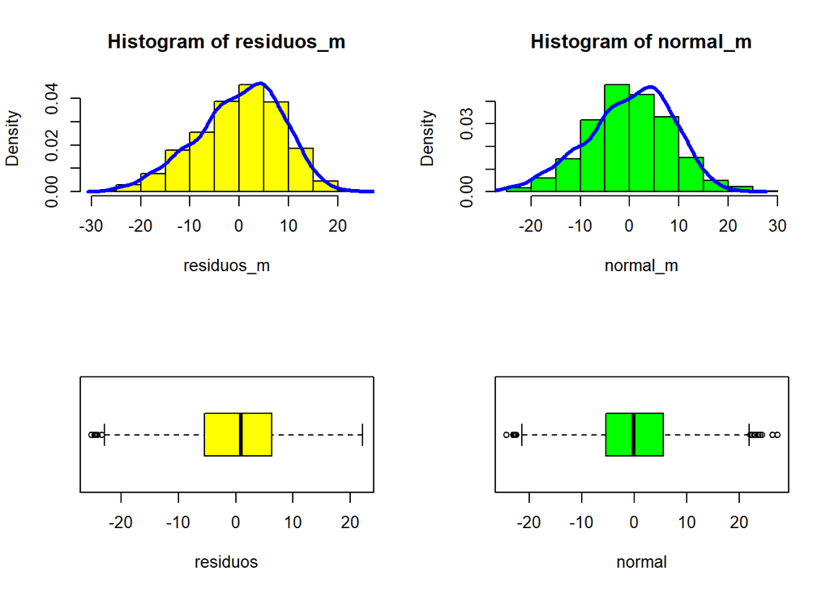

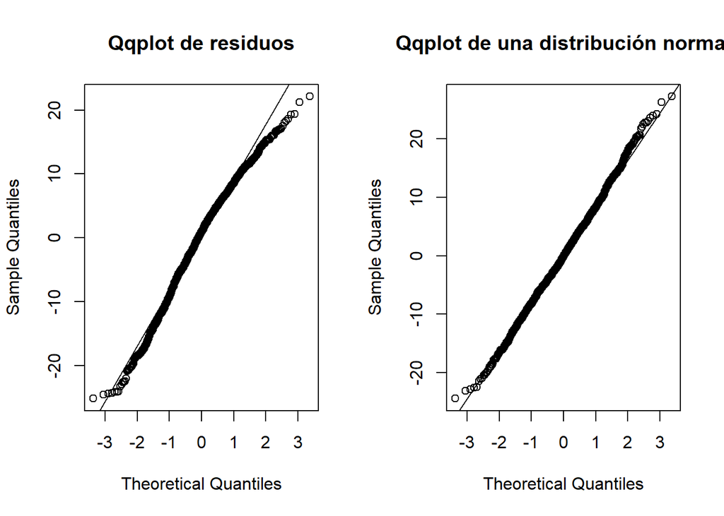

*Homocedasticidad e independencia*

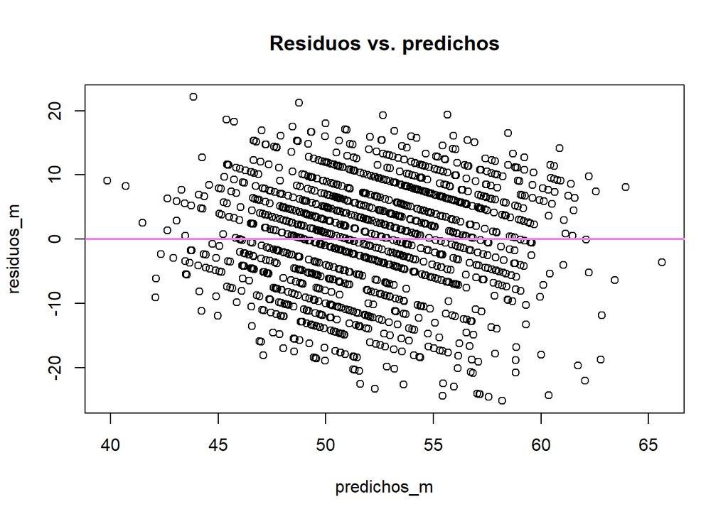

*Multicolinealidad*

*Inflación de la varianza*

[output not shown]

*Sesgo*

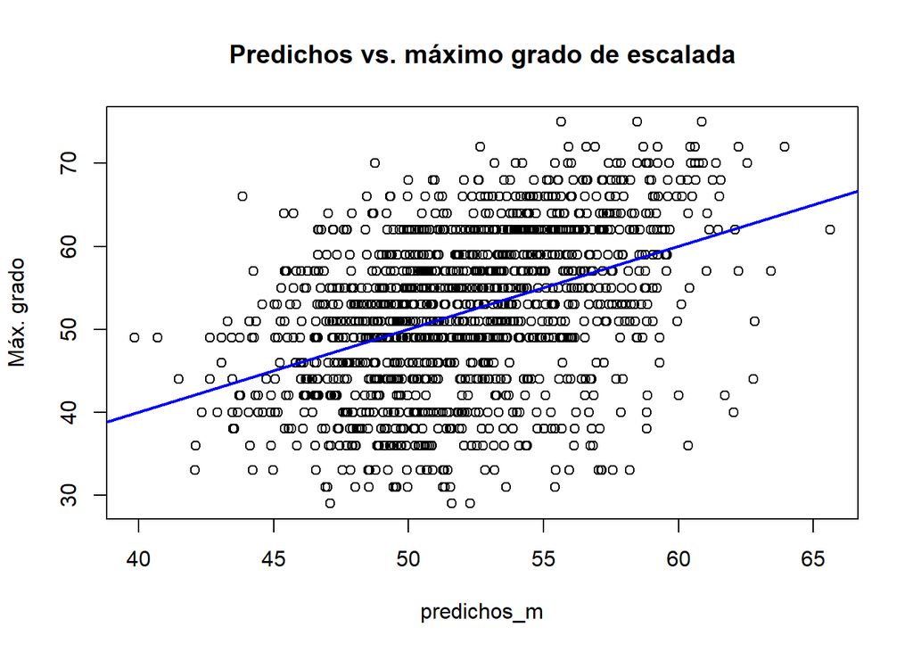

**Evaluación de los supuestos de ambos modelos (hombre y mujer)**